# Presentation of Data-Set

## Variables

- X1: number of rooms per person
- X2: Toilet availability rate in the residence
- X3: rate of persons who has quality problems in the residence(%)
- X4: Employment Rate(%)
- X5: Unemployment Rate (%)
- X6: Average income per day (TL)
- 7: Job Satisfaction Rate (%)
- X8: Savings Deposits per person
- X9: Proportion of households in the middle and higher income group
- X10: Proportion of households declaring that they cannot meet their basic needs
- X11: Infant mortality rate
- X12: life expectancy at birth
- X13: Number of applications per doctor
- X14: Health satisfaction rate
- X15: Satisfaction rate of public health services
- X16: Net enrollment rate in pre-school education (%)
- X17: Average score based on TEOG system placement
- X18: Average score based on YGS
- X19: Proportion of faculty or college graduates (%)
- X20: Satisfaction rate of public education services (%)
- X21: Average of PM10 station values (Air Pollution) (µg/m³)
- X22: Forest are per Km2 (%)
- X23: Proportion of the population provided with waste services (%)
- X24: Proportion of people experiencing noise problems from the street (%)
- X25: Satisfaction rate of the municipality’s cleaning services (%)
- X26: Murder rate per Million (bir milyon kişide)
- X27: Number of fatal and injured traffic accidents per thousand
- X28: Proportion of people who feel safe walking alone at night (%)
- X29: Satisfaction rate of public security services (%)
- X30: Participation rate in local government elections (%)
- X31: Membership rate of political parties (%)
- X32: Proportion of those related to union/association activities (%)
- X33: Number of internet subscribers per hunderd
- X34: Access rate to sewage and mains water (%)
- X35: Airport access rate
- X36: Satisfaction rate of the municipality’s public transportation services (%)
- X37: Number of cinema and theater audience per hundred
- X38: Mall area per thousand m2
- X39: Satisfaction rate from social relationships (%)
- X40: Social life satisfaction rate (%)
- X41: Happiness level (%)

```r
print(summary(data[,1:41]))
```

```
##        x1             x2              x3              x4
##  Min.   :0.75   Min.   :50.31   Min.   : 9.38   Min.   :27.80
##  1st Qu.:1.16   1st Qu.:85.71   1st Qu.:15.31   1st Qu.:43.50
##  Median :1.38   Median :89.68   Median :18.72   Median :47.20
##  Mean   :1.31   Mean   :88.06   Mean   :21.12   Mean   :46.22
##  3rd Qu.:1.49   3rd Qu.:96.21   3rd Qu.:25.64   3rd Qu.:49.90
##  Max.   :1.68   Max.   :99.92   Max.   :44.73   Max.   :59.10
##        x5               x6              x7              x8
##  Min.   : 4.200   Min.   :46.87   Min.   :63.97   Min.   :  616.2
##  1st Qu.: 6.500   1st Qu.:53.31   1st Qu.:73.60   1st Qu.: 2259.6
##  Median : 7.300   Median :56.11   Median :79.21   Median : 3899.9
##  Mean   : 8.801   Mean   :57.69   Mean   :78.77   Mean   : 4342.1
##  3rd Qu.:10.000   3rd Qu.:59.89   3rd Qu.:83.10   3rd Qu.: 5818.1
##  Max.   :23.400   Max.   :85.55   Max.   :91.60   Max.   :18131.0
##        x9             x10             x11              x12
##  Min.   :16.27   Min.   :32.78   Min.   : 5.274   Min.   :74.95
##  1st Qu.:28.78   1st Qu.:44.46   1st Qu.: 8.567   1st Qu.:77.54
##  Median :34.06   Median :47.96   Median :10.314   Median :78.00
##  Mean   :34.38   Mean   :50.95   Mean   :10.995   Mean   :78.14
##  3rd Qu.:38.92   3rd Qu.:57.17   3rd Qu.:12.869   3rd Qu.:78.70
##  Max.   :58.91   Max.   :74.95   Max.   :25.728   Max.   :80.50
##       x13            x14             x15             x16             x17
##  Min.   :2763   Min.   :59.15   Min.   :54.55   Min.   :23.53   Min.   :215.3
##  1st Qu.:4955   1st Qu.:69.32   1st Qu.:72.60   1st Qu.:30.03   1st Qu.:292.2
##  Median :5787   Median :72.02   Median :78.85   Median :35.47   Median :304.8
##  Mean   :5834   Mean   :72.00   Mean   :77.47   Mean   :35.27   Mean   :295.9
##  3rd Qu.:6774   3rd Qu.:74.29   3rd Qu.:82.59   3rd Qu.:39.45   3rd Qu.:313.8
##  Max.   :8067   Max.   :80.76   Max.   :89.13   Max.   :53.16   Max.   :338.0
##       x18             x19              x20             x21
##  Min.   :178.6   Min.   : 8.561   Min.   :48.18   Min.   : 18.00
##  1st Qu.:195.3   1st Qu.:11.728   1st Qu.:68.78   1st Qu.: 42.00
##  Median :198.6   Median :12.893   Median :74.63   Median : 53.00
##  Mean   :197.6   Mean   :13.119   Mean   :74.09   Mean   : 55.33
##  3rd Qu.:201.8   3rd Qu.:14.228   3rd Qu.:81.47   3rd Qu.: 66.00
##  Max.   :207.9   Max.   :22.653   Max.   :88.89   Max.   :113.00
##       x22                x23              x24             x25
##  Min.   : 0.04394   Min.   : 35.71   Min.   : 6.36   Min.   :30.96
##  1st Qu.:13.57082   1st Qu.: 67.85   1st Qu.:11.56   1st Qu.:55.53
##  Median :34.10988   Median : 76.82   Median :14.84   Median :67.67
##  Mean   :30.70974   Mean   : 78.73   Mean   :15.66   Mean   :63.98
```

[output cut: 15 more lines]

```
##  Max.   :93.10   Max.   :34.73   Max.   :22.080   Max.   :17.664
##       x34              x35               x36             x37
##  Min.   : 31.11   Min.   :   0.00   Min.   :23.46   Min.   :  0.2867
##  1st Qu.: 65.99   1st Qu.:  19.22   1st Qu.:51.01   1st Qu.: 19.2736
##  Median : 72.93   Median :  85.64   Median :59.70   Median : 39.1120
##  Mean   : 74.37   Mean   : 669.86   Mean   :58.39   Mean   : 45.3530
##  3rd Qu.: 88.00   3rd Qu.: 468.40   3rd Qu.:66.21   3rd Qu.: 63.7632
##  Max.   :100.00   Max.   :9874.83   Max.   :78.81   Max.   :147.4408
##       x38              x39             x40             x41
##  Min.   :  0.00   Min.   :78.23   Min.   :21.50   Min.   :41.98
##  1st Qu.:  0.00   1st Qu.:86.24   1st Qu.:46.74   1st Qu.:56.54
##  Median : 57.51   Median :89.71   Median :52.85   Median :60.39
##  Mean   : 69.54   Mean   :88.83   Mean   :54.26   Mean   :61.15
##  3rd Qu.:115.25   3rd Qu.:91.66   3rd Qu.:62.13   3rd Qu.:65.57
##  Max.   :284.01   Max.   :96.19   Max.   :80.88   Max.   :77.66
```

to understand the structure of the dataset,we looked at the summary statistics of the variables. Our observations are the 81 cities of Turkey.There are no missing value in the entire dataset.

We can see that some variables has high variances rather than other variables that is because there are metric differences between variables.these metric differences are considered at the next stages.

## *Multinormality Test*

```r
HZ.test(data)
```

```
##             Henze-Zirkler test for Multivariate Normality
##
##   data : data
##
##   HZ              : 1.000003
##   p-value         : 0.002233187
##
##   Result  : Data are not multivariate normal (sig.level = 0.05)
```

*H0 : Data distributes multivariate normality*  
*H1 : Data does not distribute multivariate normality*

if every variable is tested one by one with shapiro wilk normality test

```r
for(i in 1:ncol(data)) {
  if(shapiro.test(as.matrix(data[,i]))[2] > 0.05) {
    print(paste(i,". variable distributes normally",sep=""))
  }
}
```

```
## [1] "7. variable distributes normally"
## [1] "9. variable distributes normally"
## [1] "12. variable distributes normally"
## [1] "13. variable distributes normally"
## [1] "14. variable distributes normally"
## [1] "16. variable distributes normally"
## [1] "20. variable distributes normally"
## [1] "27. variable distributes normally"
## [1] "28. variable distributes normally"
## [1] "33. variable distributes normally"
## [1] "36. variable distributes normally"
## [1] "40. variable distributes normally"
## [1] "41. variable distributes normally"
```

the indexes of variables that ditributes normally are listed above.

## Correlation Matrix

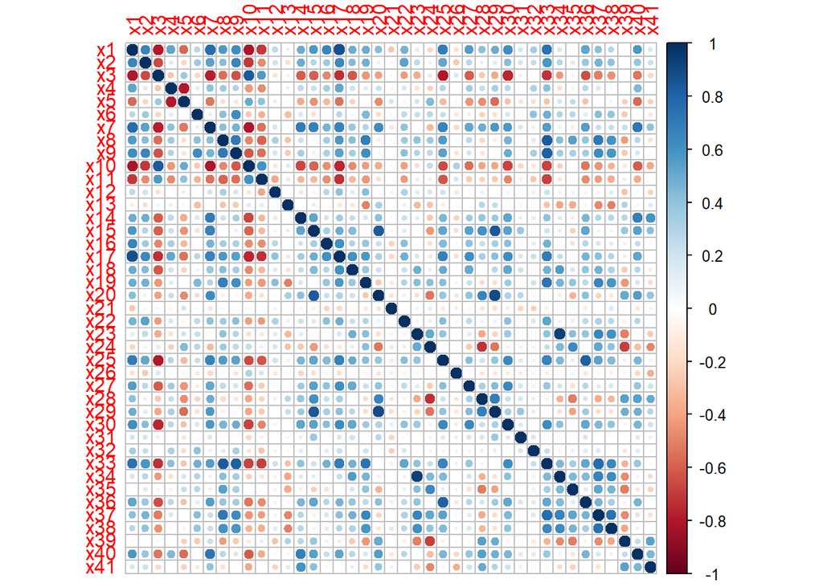

```r
corrplot(cor(data))
```

at the correlation graph above, it is seen that there are highly correlated variables in the dataset.

### List of Correlated Variables

```r
# indexes of correlated variables
cor_index <- which((cor(data)>0.7) | (cor(data)< -0.7),arr.ind = T)

# correlation matrix is a symmetric matrix so repeated indexes are deleted
d_index <- c()
for(i in 1:103) {
  if (cor_index[i,1] == cor_index[i,2]) {
    d_index <- c(d_index,i)
  }
}
cor_index <- cor_index[-d_index,]

dd_index <- c()
for(i in 1:62) {
  if(i == 62) {
    break
  }
  for(x in ((i+1):62)) {
    if (all(c(cor_index[i,1],cor_index[i,2]) == c(cor_index[x,2],cor_index[x,1]))) {
      dd_index <- c(dd_index,x)
    }
  }
}


cor_index <- cor_index[-dd_index,]
rownames(cor_index) <- NULL
print(cor_index)
```

```
##       row col
##  [1,]   3   1
##  [2,]   7   1
##  [3,]  10   1
##  [4,]  11   1
##  [5,]  17   1
##  [6,]  33   1
##  [7,]  10   2
##  [8,]   7   3
##  [9,]  10   3
## [10,]  17   3
## [11,]  25   3
## [12,]  30   3
## [13,]  33   3
## [14,]   5   4
```

[output cut: 17 more lines]

### Determinant of Correlation Matrix

$$|cor(data)| = 6.27e^{-23}$$
determinant of correlation matrix is calculated approximately 0.There is multicollinearity problem in the dataset.That information tells us dataset is proper for Principal Component Analyis.